# Final project - Gender Inequality in Income

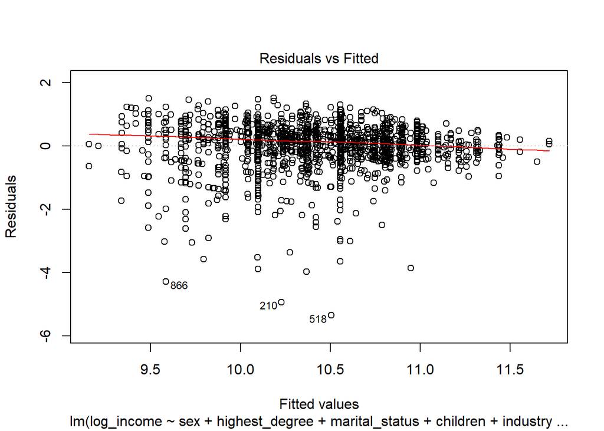

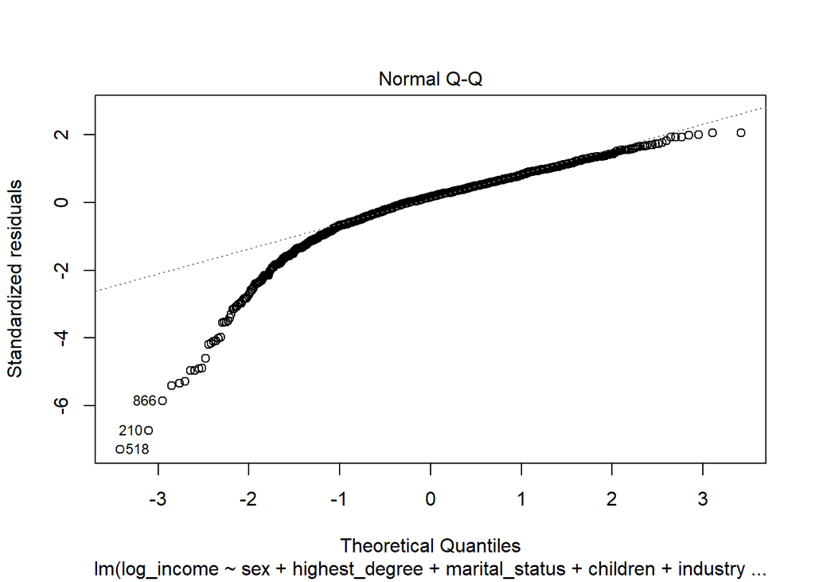

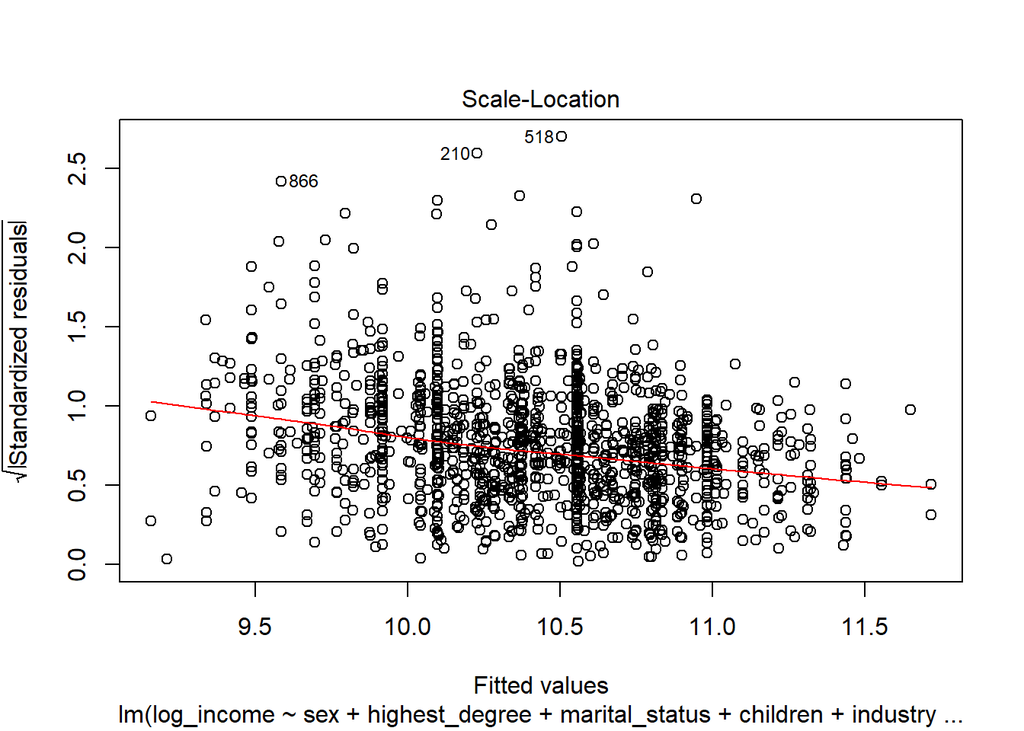

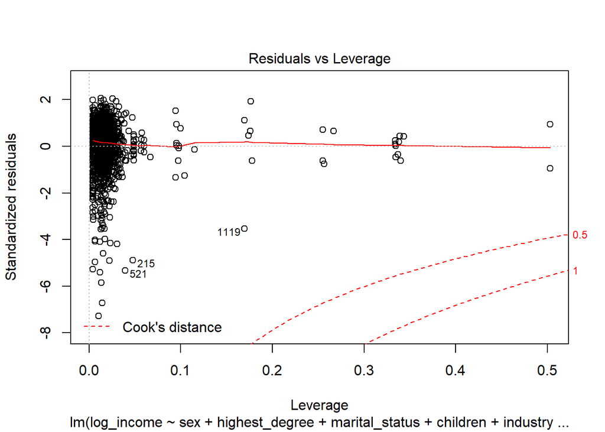

```r
nlsy.lm.edu.interact2 <- lm(log_income ~ sex + highest_degree + marital_status + children + industry + sex * highest_degree, data = nlsy.copy6)

plot(nlsy.lm.edu.interact2)
```

> Comparing with the previous model, the non-linearity problem is solved, and the outliers issue is improved. However, the residuals still appear non-normal, and there is a decreasing trend in residual variance.

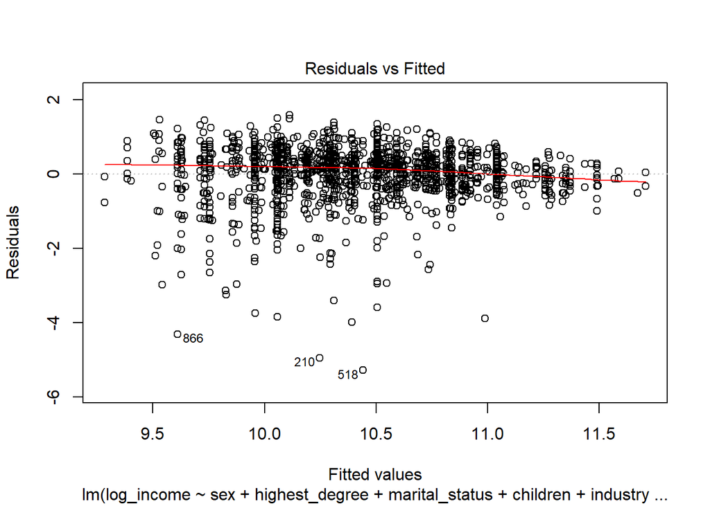

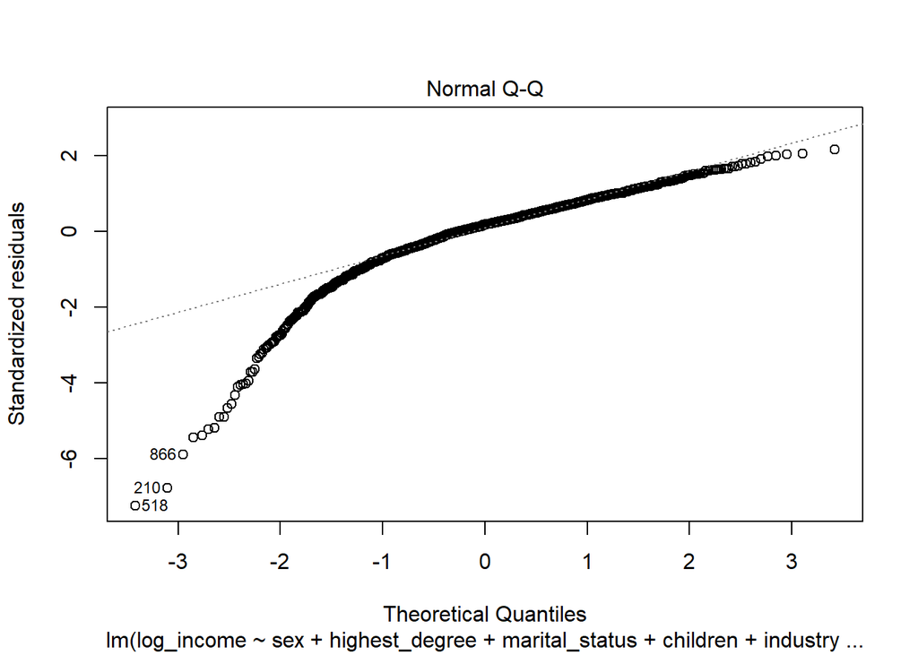

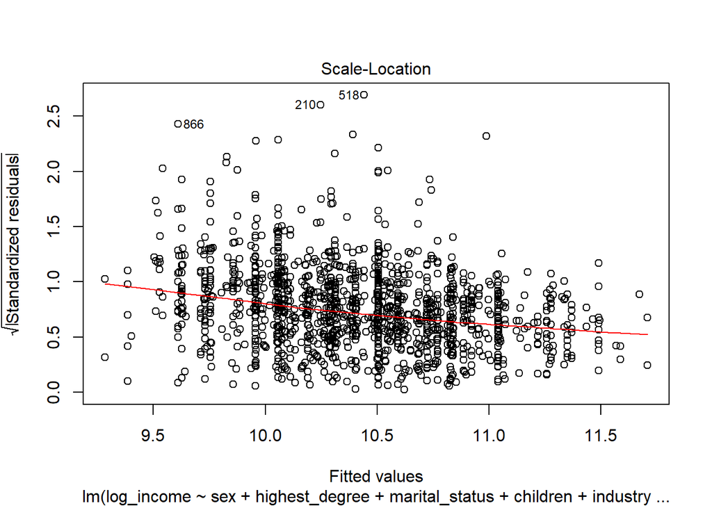

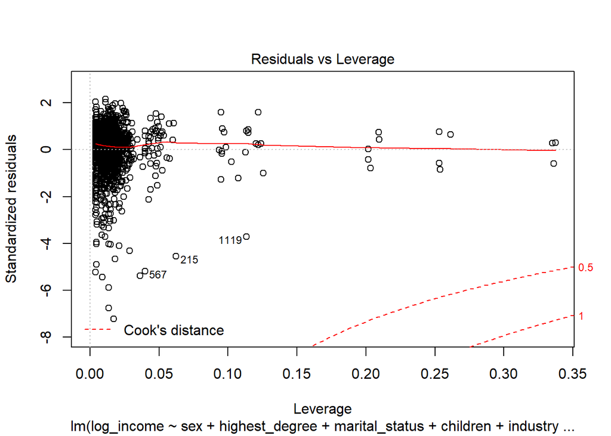

```r
nlsy.lm.mari.interact2 <- lm(log_income ~ sex + highest_degree + marital_status + children + industry + sex * marital_status, data = nlsy.copy6)

plot(nlsy.lm.mari.interact2)
```

> Similarly, the non-linearity problem is solved and the outliers issue is improved. However, the residuals still appear non-normal, and there is a decreasing trend in residual variance.

### e. Discussion

#### e-1. Main Findings

> In the next section, we will interpret the final two models: `nlsy.lm.edu.interact2` and `nlsy.lm.mari.interact2`.

> Firstly, we will interpret the `nlsy.lm.edu.interact2` model.

```r
summary(nlsy.lm.edu.interact2)
```

```
##
## Call:
## lm(formula = log_income ~ sex + highest_degree + marital_status +
##     children + industry + sex * highest_degree, data = nlsy.copy6)
##
## Residuals:
##     Min      1Q  Median      3Q     Max
## -5.3502 -0.2873  0.1204  0.4379  1.5106
##
## Coefficients:
##                                        Estimate Std. Error t value Pr(>|t|)
## (Intercept)                             9.66509    0.13864  69.712  < 2e-16 ***
## sexMale                                 0.66453    0.12917   5.145 3.02e-07 ***
## highest_degreeGED                       0.20706    0.12035   1.721 0.085536 .
## highest_degreeHigh School               0.42792    0.09803   4.365 1.35e-05 ***
## highest_degreeAssociate/Junior          0.75006    0.12453   6.023 2.13e-09 ***
## highest_degreeBachelor's                0.88367    0.10773   8.202 4.88e-16 ***
## highest_degreeMaster's                  1.14343    0.14639   7.811 1.03e-14 ***
## highest_degreePhD                       1.47291    0.43717   3.369 0.000772 ***
## highest_degreeProfessional              0.86878    0.31615   2.748 0.006065 **
## marital_statusMarried                   0.18192    0.04493   4.049 5.40e-05 ***
## marital_statusSeparated                -0.12070    0.10926  -1.105 0.269468
## marital_statusDivorced                  0.12667    0.06450   1.964 0.049737 *
## marital_statusWidowed                  -0.22800    0.37407  -0.610 0.542269
## childrenYes                             0.27785    0.06527   4.257 2.20e-05 ***
## industryAGRICULTURE                    -0.21909    0.24002  -0.913 0.361489
## industryCONSTRUCTION                   -0.18069    0.11379  -1.588 0.112508
## industryFINANCE                        -0.12418    0.12363  -1.004 0.315317
## industryMANUFACTURING                  -0.22326    0.11077  -2.016 0.044018 *
## industryMILITARY                        0.02265    0.43657   0.052 0.958623
## industryMINING                         -0.26879    0.11283  -2.382 0.017332 *
## industryPUBLIC ADMINISTRATION          -0.11500    0.11753  -0.979 0.327966
## industryRETAIL TRADE                   -0.78689    0.11554  -6.811 1.38e-11 ***
## industrySERVICES                       -0.45554    0.09109  -5.001 6.35e-07 ***
## industryUTILITIES                      -0.21054    0.10640  -1.979 0.048018 *
## sexMale:highest_degreeGED              -0.17433    0.16380  -1.064 0.287383
## sexMale:highest_degreeHigh School      -0.20305    0.13651  -1.487 0.137097
## sexMale:highest_degreeAssociate/Junior -0.41251    0.18395  -2.243 0.025069 *
## sexMale:highest_degreeBachelor's       -0.23622    0.15453  -1.529 0.126573
## sexMale:highest_degreeMaster's         -0.37889    0.23500  -1.612 0.107100
## sexMale:highest_degreePhD              -0.15643    0.68787  -0.227 0.820133
## sexMale:highest_degreeProfessional      0.51371    0.53895   0.953 0.340646
## ---
## Signif. codes:  0 '***' 0.001 '**' 0.01 '*' 0.05 '.' 0.1 ' ' 1
##
## Residual standard error: 0.738 on 1560 degrees of freedom
## Multiple R-squared:  0.2683, Adjusted R-squared:  0.2542
## F-statistic: 19.07 on 30 and 1560 DF,  p-value: < 2.2e-16
```

```r
kable(coef(summary(nlsy.lm.edu.interact2)), digits = c(3, 3, 2, 4))
```

|  | Estimate | Std. Error | t value | Pr(>\|t\|) |
| --- | --- | --- | --- | --- |
| (Intercept) | 9.665 | 0.139 | 69.71 | 0.0000 |
| sexMale | 0.665 | 0.129 | 5.14 | 0.0000 |
| highest_degreeGED | 0.207 | 0.120 | 1.72 | 0.0855 |
| highest_degreeHigh School | 0.428 | 0.098 | 4.37 | 0.0000 |
| highest_degreeAssociate/Junior | 0.750 | 0.125 | 6.02 | 0.0000 |
| highest_degreeBachelor’s | 0.884 | 0.108 | 8.20 | 0.0000 |
| highest_degreeMaster’s | 1.143 | 0.146 | 7.81 | 0.0000 |
| highest_degreePhD | 1.473 | 0.437 | 3.37 | 0.0008 |
| highest_degreeProfessional | 0.869 | 0.316 | 2.75 | 0.0061 |
| marital_statusMarried | 0.182 | 0.045 | 4.05 | 0.0001 |
| marital_statusSeparated | -0.121 | 0.109 | -1.10 | 0.2695 |
| marital_statusDivorced | 0.127 | 0.065 | 1.96 | 0.0497 |
| marital_statusWidowed | -0.228 | 0.374 | -0.61 | 0.5423 |
| childrenYes | 0.278 | 0.065 | 4.26 | 0.0000 |
| industryAGRICULTURE | -0.219 | 0.240 | -0.91 | 0.3615 |
| industryCONSTRUCTION | -0.181 | 0.114 | -1.59 | 0.1125 |
| industryFINANCE | -0.124 | 0.124 | -1.00 | 0.3153 |
| industryMANUFACTURING | -0.223 | 0.111 | -2.02 | 0.0440 |
| industryMILITARY | 0.023 | 0.437 | 0.05 | 0.9586 |
| industryMINING | -0.269 | 0.113 | -2.38 | 0.0173 |
| industryPUBLIC ADMINISTRATION | -0.115 | 0.118 | -0.98 | 0.3280 |
| industryRETAIL TRADE | -0.787 | 0.116 | -6.81 | 0.0000 |
| industrySERVICES | -0.456 | 0.091 | -5.00 | 0.0000 |
| industryUTILITIES | -0.211 | 0.106 | -1.98 | 0.0480 |
| sexMale:highest_degreeGED | -0.174 | 0.164 | -1.06 | 0.2874 |
| sexMale:highest_degreeHigh School | -0.203 | 0.137 | -1.49 | 0.1371 |
| sexMale:highest_degreeAssociate/Junior | -0.413 | 0.184 | -2.24 | 0.0251 |
| sexMale:highest_degreeBachelor’s | -0.236 | 0.155 | -1.53 | 0.1266 |
| sexMale:highest_degreeMaster’s | -0.379 | 0.235 | -1.61 | 0.1071 |
| sexMale:highest_degreePhD | -0.156 | 0.688 | -0.23 | 0.8201 |
| sexMale:highest_degreeProfessional | 0.514 | 0.539 | 0.95 | 0.3406 |

> Holding other variables constant, males have 66.45% higher income than females on average. Generally, higher education level is associated with higher income. Married and divoced status are associated with higher income than never-married. And holding other variables constant, having children is associated with 27.79% higher income than no children on average. The `retail trade` industry seems to have the lowest average income, while the `military` industry seems to have the highest average income. In terms of the interaction effect of `sex:highest_degree`, the only statistically significant term is the coefficient of `sexMale:highest_degreeAssociate/Junior`, indicating that for respondents with Associate/Junior degree, the income gap between males and females decreases by 41.25% from respondents with no degree.

> Next, we will interpret the `nlsy.lm.mari.interact2` model:

```r
summary(nlsy.lm.mari.interact2)
```

```
##
## Call:
## lm(formula = log_income ~ sex + highest_degree + marital_status +
##     children + industry + sex * marital_status, data = nlsy.copy6)
##
## Residuals:
##     Min      1Q  Median      3Q     Max
## -5.2887 -0.2957  0.1290  0.4352  1.5831
##
## Coefficients: (1 not defined because of singularities)
##                                  Estimate Std. Error t value Pr(>|t|)
## (Intercept)                      9.850065   0.127627  77.179  < 2e-16 ***
## sexMale                          0.358049   0.072842   4.915 9.79e-07 ***
## highest_degreeGED                0.126321   0.081382   1.552 0.120818
## highest_degreeHigh School        0.327007   0.068654   4.763 2.08e-06 ***
## highest_degreeAssociate/Junior   0.563654   0.091686   6.148 9.96e-10 ***
## highest_degreeBachelor's         0.775826   0.079068   9.812  < 2e-16 ***
## highest_degreeMaster's           0.993103   0.115022   8.634  < 2e-16 ***
## highest_degreePhD                1.406234   0.337336   4.169 3.23e-05 ***
## highest_degreeProfessional       1.005907   0.255132   3.943 8.41e-05 ***
## marital_statusMarried            0.102091   0.058757   1.738 0.082492 .
## marital_statusSeparated          0.004291   0.151754   0.028 0.977446
## marital_statusDivorced           0.120192   0.083876   1.433 0.152064
## marital_statusWidowed           -0.212393   0.373389  -0.569 0.569556
## childrenYes                      0.226857   0.066551   3.409 0.000669 ***
## industryAGRICULTURE             -0.219453   0.239442  -0.917 0.359537
## industryCONSTRUCTION            -0.154359   0.113050  -1.365 0.172323
## industryFINANCE                 -0.139367   0.123363  -1.130 0.258763
## industryMANUFACTURING           -0.213695   0.110468  -1.934 0.053237 .
## industryMILITARY                -0.054901   0.435715  -0.126 0.899747
## industryMINING                  -0.271537   0.112565  -2.412 0.015968 *
## industryPUBLIC ADMINISTRATION   -0.120190   0.117223  -1.025 0.305374
## industryRETAIL TRADE            -0.793617   0.115323  -6.882 8.53e-12 ***
## industrySERVICES                -0.449126   0.090907  -4.940 8.63e-07 ***
## industryUTILITIES               -0.203721   0.106098  -1.920 0.055023 .
## sexMale:marital_statusMarried    0.177663   0.086445   2.055 0.040024 *
## sexMale:marital_statusSeparated -0.263974   0.218037  -1.211 0.226198
## sexMale:marital_statusDivorced   0.008993   0.129636   0.069 0.944702
## sexMale:marital_statusWidowed          NA         NA      NA       NA
## ---
## Signif. codes:  0 '***' 0.001 '**' 0.01 '*' 0.05 '.' 0.1 ' ' 1
##
## Residual standard error: 0.737 on 1564 degrees of freedom
## Multiple R-squared:  0.2683, Adjusted R-squared:  0.2561
## F-statistic: 22.06 on 26 and 1564 DF,  p-value: < 2.2e-16
```

```r
kable(coef(summary(nlsy.lm.mari.interact2)), digits = c(3, 3, 2, 4))
```

|  | Estimate | Std. Error | t value | Pr(>\|t\|) |
| --- | --- | --- | --- | --- |
| (Intercept) | 9.850 | 0.128 | 77.18 | 0.0000 |
| sexMale | 0.358 | 0.073 | 4.92 | 0.0000 |
| highest_degreeGED | 0.126 | 0.081 | 1.55 | 0.1208 |
| highest_degreeHigh School | 0.327 | 0.069 | 4.76 | 0.0000 |
| highest_degreeAssociate/Junior | 0.564 | 0.092 | 6.15 | 0.0000 |
| highest_degreeBachelor’s | 0.776 | 0.079 | 9.81 | 0.0000 |
| highest_degreeMaster’s | 0.993 | 0.115 | 8.63 | 0.0000 |
| highest_degreePhD | 1.406 | 0.337 | 4.17 | 0.0000 |
| highest_degreeProfessional | 1.006 | 0.255 | 3.94 | 0.0001 |
| marital_statusMarried | 0.102 | 0.059 | 1.74 | 0.0825 |
| marital_statusSeparated | 0.004 | 0.152 | 0.03 | 0.9774 |
| marital_statusDivorced | 0.120 | 0.084 | 1.43 | 0.1521 |
| marital_statusWidowed | -0.212 | 0.373 | -0.57 | 0.5696 |
| childrenYes | 0.227 | 0.067 | 3.41 | 0.0007 |
| industryAGRICULTURE | -0.219 | 0.239 | -0.92 | 0.3595 |
| industryCONSTRUCTION | -0.154 | 0.113 | -1.37 | 0.1723 |
| industryFINANCE | -0.139 | 0.123 | -1.13 | 0.2588 |
| industryMANUFACTURING | -0.214 | 0.110 | -1.93 | 0.0532 |
| industryMILITARY | -0.055 | 0.436 | -0.13 | 0.8997 |
| industryMINING | -0.272 | 0.113 | -2.41 | 0.0160 |
| industryPUBLIC ADMINISTRATION | -0.120 | 0.117 | -1.03 | 0.3054 |
| industryRETAIL TRADE | -0.794 | 0.115 | -6.88 | 0.0000 |
| industrySERVICES | -0.449 | 0.091 | -4.94 | 0.0000 |
| industryUTILITIES | -0.204 | 0.106 | -1.92 | 0.0550 |
| sexMale:marital_statusMarried | 0.178 | 0.086 | 2.06 | 0.0400 |
| sexMale:marital_statusSeparated | -0.264 | 0.218 | -1.21 | 0.2262 |
| sexMale:marital_statusDivorced | 0.009 | 0.130 | 0.07 | 0.9447 |

> Holding other variables constant, males have 35.80% higher income than females on average. This income gap estimation seems to be a lot smaller than the `nlsy.lm.edu.interact2` model estimation. Generally, higher education level is associated with higher income. The coefficients of marital status became not significant. Holding other variables constant, having children is associated with 22.69% higher income than no children on average. In terms of the interaction effect of `sex:marital_status`, the only statistically significant term is the coefficient of `sexMale:marital_statusMarried`, indicating that for married respondents, the income gap between males and females increases by 17.77% from respondents who are not married.

> Both the descriptive statistics and the regression models show that for respondents who are married or with children, the income gaps between men and women are larger than respondents who are not married or without children. They also show that there is no clear trend that as education level increases, the incom gap increases or decreases, although the interaction term is statistically significant.

> Although in the descriptive statistics section, we find a positive relationship between how much respondents evaluate themselves as `organized` or `trustful` with `income`, after controlling for other varibales, these relationships became not statistically significant.

#### e-2. Limitations and Confidence in Analysis

##### Limitations

> *Non-normal distribution of residuals* The Normal QQ plot indicates that the residuals are not normally distributed, but since we have a very large sample size, this may not cause a very serious problem.

> *Heteroscedasticity* There is a slightly decreasing trend in residual variance, so the standard errors may be biased. Because the standard error is central to conducting significance tests and calculating confidence intervals, biased standard errors may lead to incorrect conclusions about the significance of the regression coefficients.

> *Military industry deleted* Since there’s no female respondent in the military industry, we removed this industry in order to perform t-test on income gap between men and women. This is the limitation of the sampling of this study. We were unable to examine the income inequality between men and women in military.

##### Confidence in Analysis

> We have moderate confidence in our findings. The sample size is big even after removing missing values. We used modified t-tests so that they won’t be biased by counts less than 5. There is no non-linearity or collinearity problem of our linear model. However, the heteroscedasticity and outlier issues exist.

> If policy makers would refer to our analysis, we would recommend not to omit the effect of a variable only because the regression coefficient is not statistically significant, due to the limitations of the sampling and the regression models discussed before and some other possible omitted variable bias.